# Perspectives on Computational Research: Problem Set #3

Xingyun Wu

2017/5/14

## Part I: Regression Diagnostics

### 1. unusual and/or influential observations

According to the results of the model, variable `female` and `educ` are statisticaly significant on the level of 0.000. And the variable `age` is not statistically significant.

```
##
## Call:
## lm(formula = biden ~ age + female + educ, data = biden_data)
##
## Residuals:
##    Min     1Q Median     3Q    Max
##  -67.1  -14.7    0.7   18.9   45.1
##
## Coefficients:
##             Estimate Std. Error t value Pr(>|t|)
## (Intercept)  68.6210     3.5960   19.08  < 2e-16 ***
## age           0.0419     0.0325    1.29      0.2
## female        6.1961     1.0967    5.65  1.9e-08 ***
## educ         -0.8887     0.2247   -3.96  7.9e-05 ***
## ---
## Signif. codes:  0 '***' 0.001 '**' 0.01 '*' 0.05 '.' 0.1 ' ' 1
##
## Residual standard error: 23.2 on 1803 degrees of freedom
## Multiple R-squared:  0.0272, Adjusted R-squared:  0.0256
## F-statistic: 16.8 on 3 and 1803 DF,  p-value: 8.88e-11
```

The plot below shows the bubble plot of leverage, discrepancy, and influence, indicating unusual and influential observations.

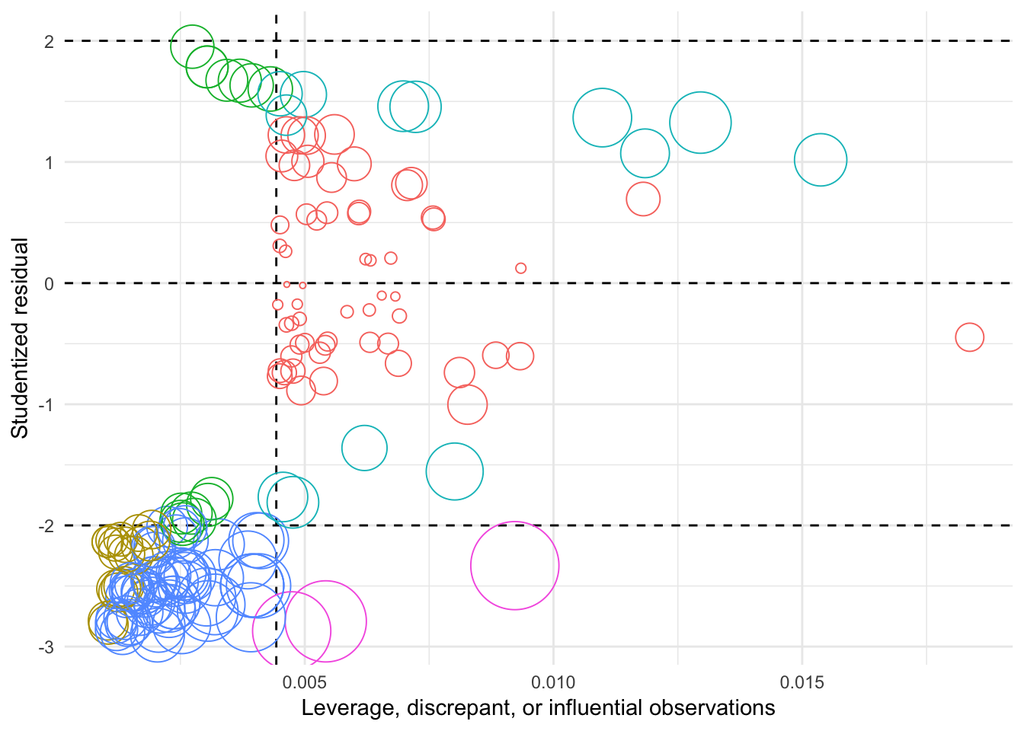

There are 167 unusual and influential observations. 90 have high influence. 74 have high leverage. And 82 have high discrepancy. Since there are many unusual and influential observations, and the interactions among these features are complex, we need very careful consideration to decide how we would deal with these observations. Here I would make the decision on the basis of the distribution of unusual and influential observations on `gender`.

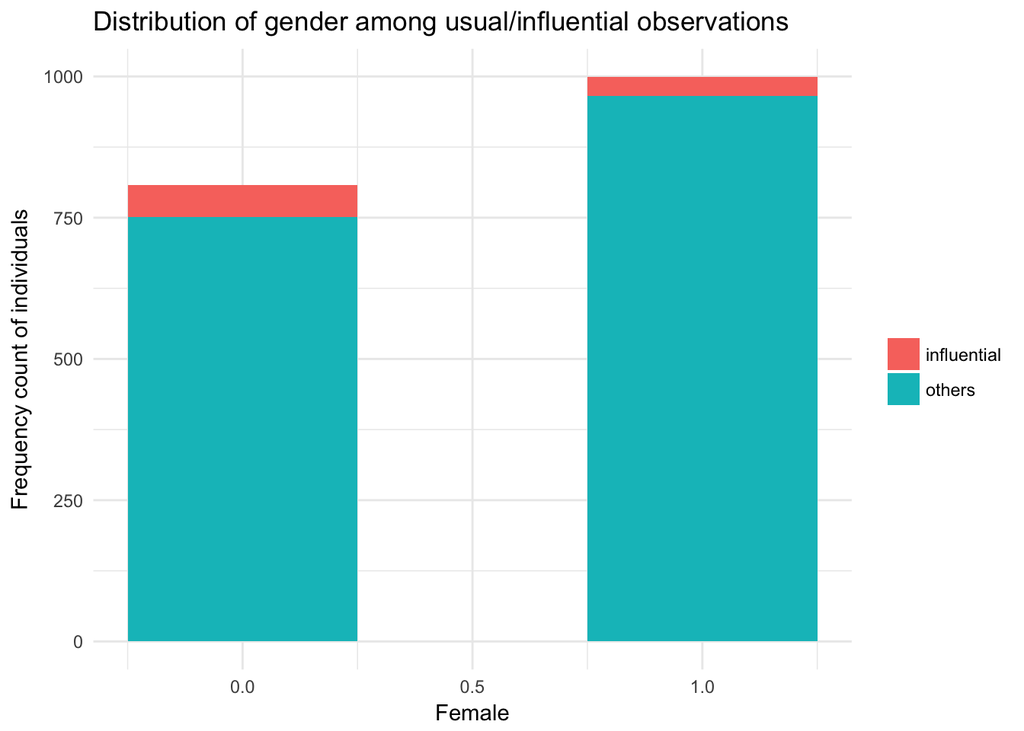

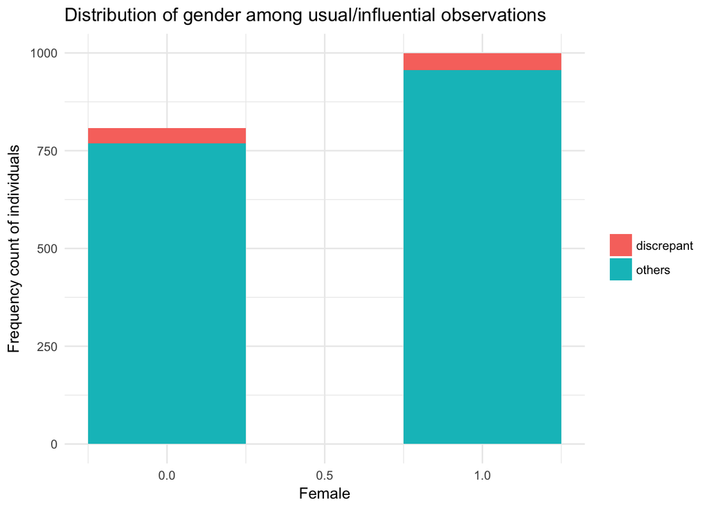

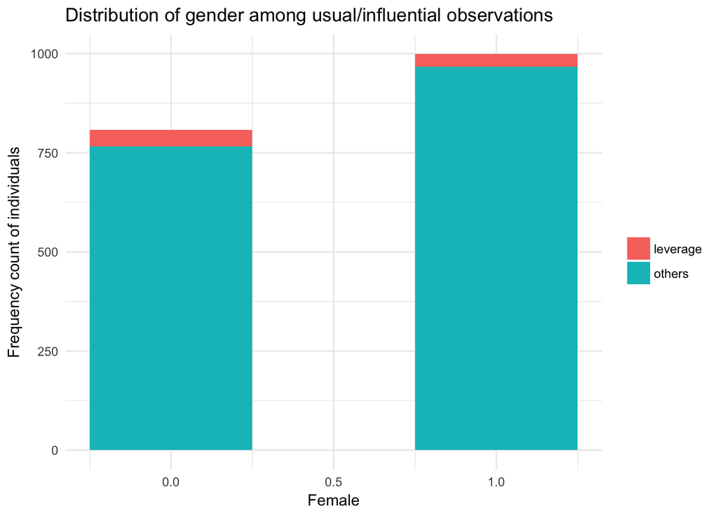

According to the bar plots above, the distributions of leverage, discrepant, and influential observations are not random. We don’t have equal proportions of unusual and influential observations over all observations with the same gender. Simply dropping these observations may cause bias. Also, respecifying the model would not help much in this case. I would try collecting additional variables to control for this influential effect. For this dataset, there are only `rep` and `dem` left unusued. So I would add these two variables to the model, and then check whether adding the two controlling variables could help solve the problem.

### 2. Test for non-normally distributed errors

The quantile-comparison plot is shown as below. According to the plot, some observations fall out side of the 95% confidence intervals, indicating that the errors are not distributed normally. The assumption of normal distribution of errors is violated. From the density plot of the studentized residual, we could also see that the residuals are skewed.

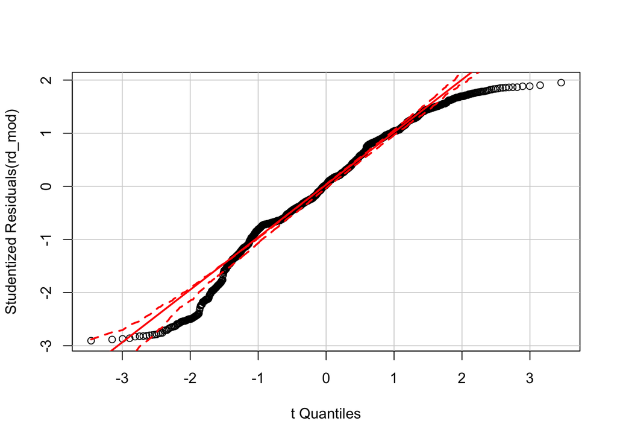

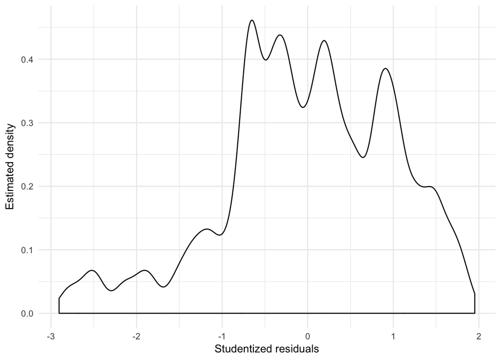

Power and log transformations are typically used to correct this problem. However, the log transformation of 0 would lead to missing value, which would cause problems to the regression model. So I tried the power transformation to the variable `biden`. I squared `biden` and perform another linear regression model. However, according to the new quantile-comparison plot, the problem of non-normally distributed errors is not solved well. The new model has even more serious non-normally distributed errors. Thus we need further consideration for the solution.

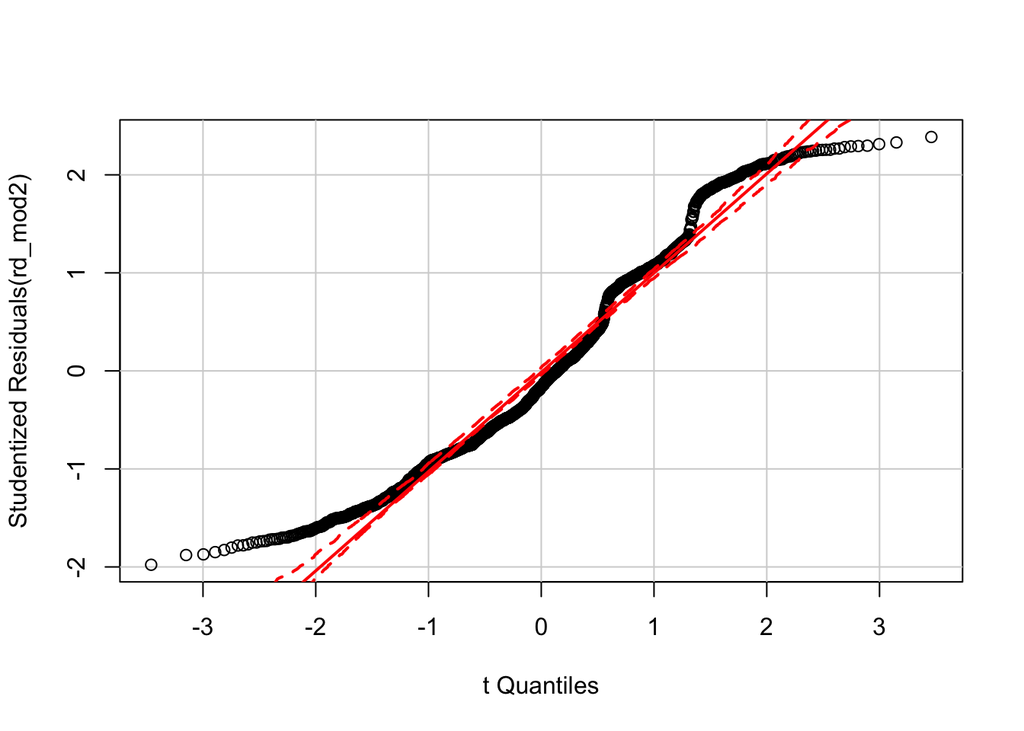

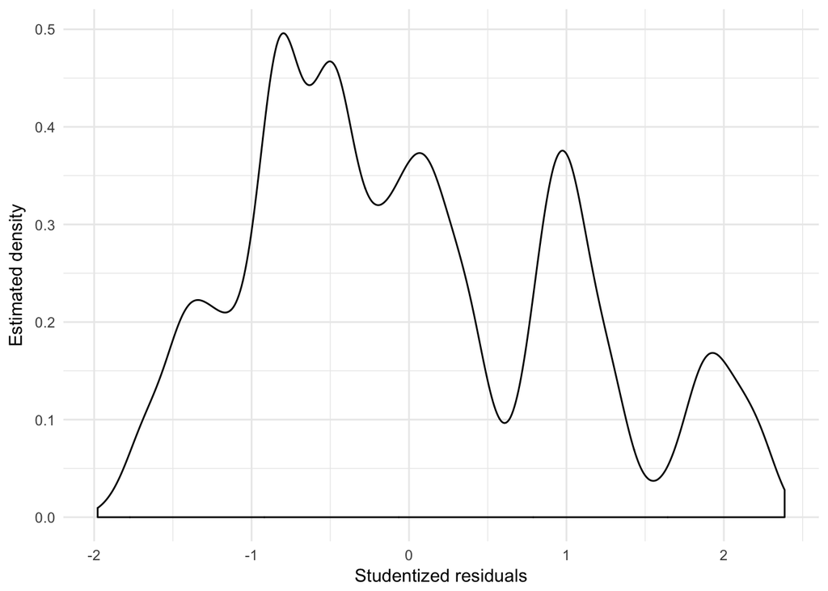

### 3. Test for heteroscedasticity in the model

According to the residual plot, the variance of the error term of each observation is not constant. The problem of heteroscedasticity exists in this model.

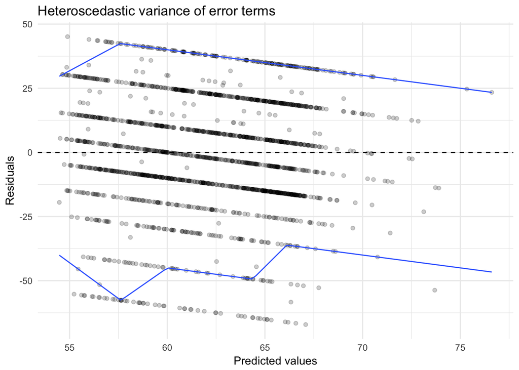

According to the result of Breusch-Pagan test, heteroscedasticity exists.

```
##
##  studentized Breusch-Pagan test
##
## data:  rd_mod
## BP = 20, df = 3, p-value = 5e-05
```

Since heteroscedasticity exists, the estimates of the standard errors will be inaccurate, leading to incorrect inferences about the statistical significance of predictor variables `age`, `gender` and `educ`.

### 4. Test for multicollinearity

The plot and VIF show that there is no multicollinearity in this model. `age`, `gender` and `educ` are not correlated with eath other. The plot doesn’t support correlation between any two of the variables. And since none of the values in the VIF is above 10, again, there is no multicollinearity among these variables.

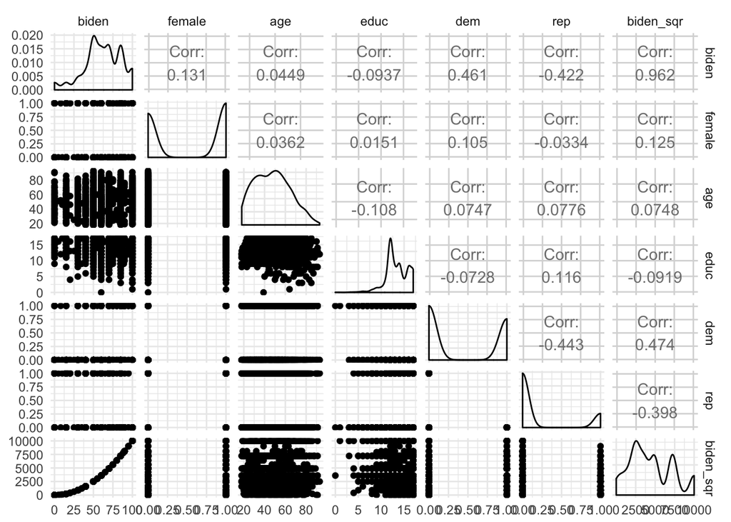

```
##    age female   educ
##   1.01   1.00   1.01
```

## Part II: Interaction Terms

```
##
## Call:
## lm(formula = biden ~ age * educ, data = biden_data)
##
## Residuals:
##    Min     1Q Median     3Q    Max
## -70.54 -12.24  -0.94  20.50  44.74
##
## Coefficients:
##             Estimate Std. Error t value Pr(>|t|)
## (Intercept)  38.3735     9.5636    4.01  6.3e-05 ***
## age           0.6719     0.1705    3.94  8.4e-05 ***
## educ          1.6574     0.7140    2.32    2e-02 *
## age:educ     -0.0480     0.0129   -3.72    2e-04 ***
## ---
## Signif. codes:  0 '***' 0.001 '**' 0.01 '*' 0.05 '.' 0.1 ' ' 1
##
## Residual standard error: 23.3 on 1803 degrees of freedom
## Multiple R-squared:  0.0176, Adjusted R-squared:  0.0159
## F-statistic: 10.7 on 3 and 1803 DF,  p-value: 5.37e-07
```

### 1. Marginal effect of age on Joe Biden thermometer rating, conditional on education

[figure not shown]

```
## Linear hypothesis test
##
## Hypothesis:
## age  + age:educ = 0
##
## Model 1: restricted model
## Model 2: biden ~ age * educ
##
##   Res.Df    RSS Df Sum of Sq    F Pr(>F)
## 1   1804 985149
## 2   1803 976688  1      8461 15.6  8e-05 ***
## ---
## Signif. codes:  0 '***' 0.001 '**' 0.01 '*' 0.05 '.' 0.1 ' ' 1
```

### 2. Marginal effect of education on Joe Biden thermometer rating, conditional on age

According to the plot, the direction of the marginal effect is negative. The magnitude is also shown in the plot. The marginal effect of education is statistically significant on the level of 0.05.

[figure not shown]

```
## Linear hypothesis test
##
## Hypothesis:
## educ  + age:educ = 0
##
## Model 1: restricted model
## Model 2: biden ~ age * educ
##
##   Res.Df    RSS Df Sum of Sq    F Pr(>F)
## 1   1804 979537
## 2   1803 976688  1      2849 5.26  0.022 *
## ---
## Signif. codes:  0 '***' 0.001 '**' 0.01 '*' 0.05 '.' 0.1 ' ' 1
```

## Part III: Missing Data

### Multivariate normality assumptions

According to the result of Mardia’s multivariate normality test, data are not multivariate normal. And the corresponding qqplot supports this conclusion. The qqplots on each of the variable show that variable `educ` violates the normality assumption. Although `gender` also violates normality assumption, this makes sense, since `gender` is a dichotomous variable. Although `age` does not perfectly fit the normal distribution, its distribution is very close. We should consider variable transformation on `educ`.

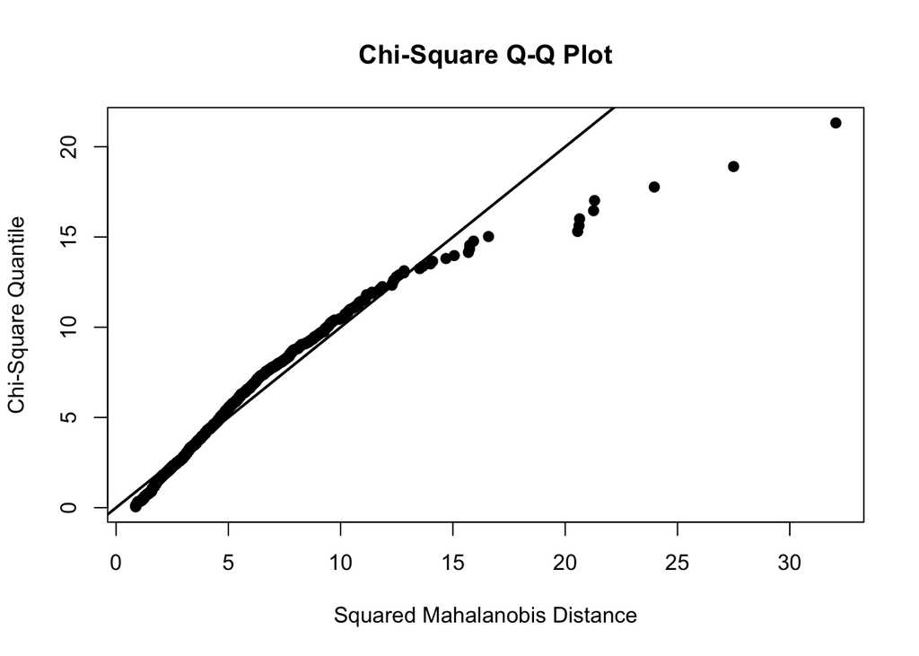

```
##    Mardia's Multivariate Normality Test
## ---------------------------------------
##    data : biden_used
##
##    g1p            : 1.08
##    chi.skew       : 329
##    p.value.skew   : 8.13e-58
##
##    g2p            : 23.2
##    z.kurtosis     : -2.47
##    p.value.kurt   : 0.0133
##
##    chi.small.skew : 330
##    p.value.small  : 5.68e-58
##
##    Result          : Data are not multivariate normal.
## ---------------------------------------
```

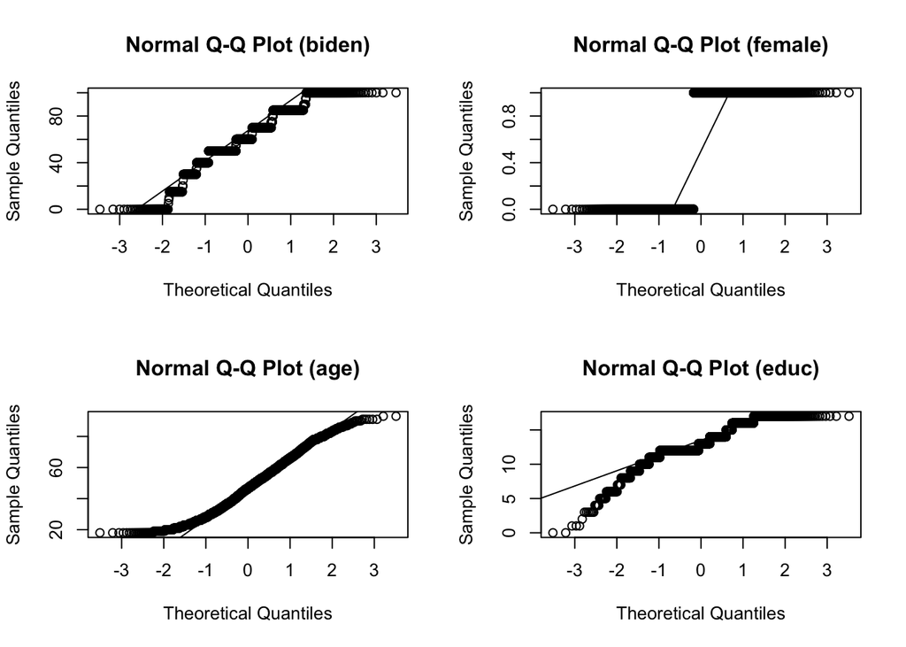

### Variables transformation

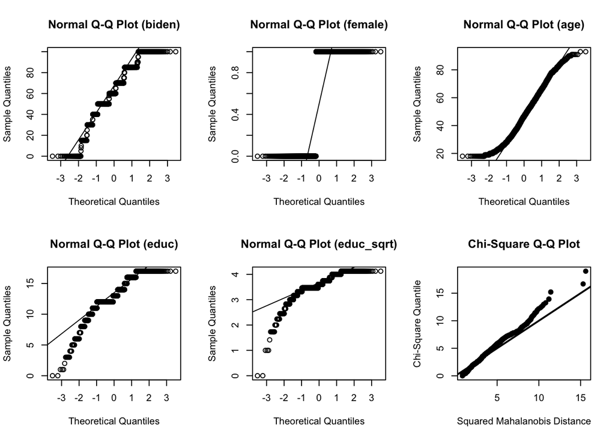

```
##    Mardia's Multivariate Normality Test
## ---------------------------------------
##    data : biden_trans
##
##    g1p            : 0.418
##    chi.skew       : 127
##    p.value.skew   : 1.58e-22
##
##    g2p            : 12.6
##    z.kurtosis     : -9.32
##    p.value.kurt   : 0
##
##    chi.small.skew : 128
##    p.value.small  : 1.37e-22
##
##    Result          : Data are not multivariate normal.
## ---------------------------------------
```

### Multiple imputation

Firstly, check the missingness of the data. According to the missingness map, there are many missing values in `biden`, some missing values in `age`, a few missing values in `educ`, and almost (or completely) no missing value in `gender`.

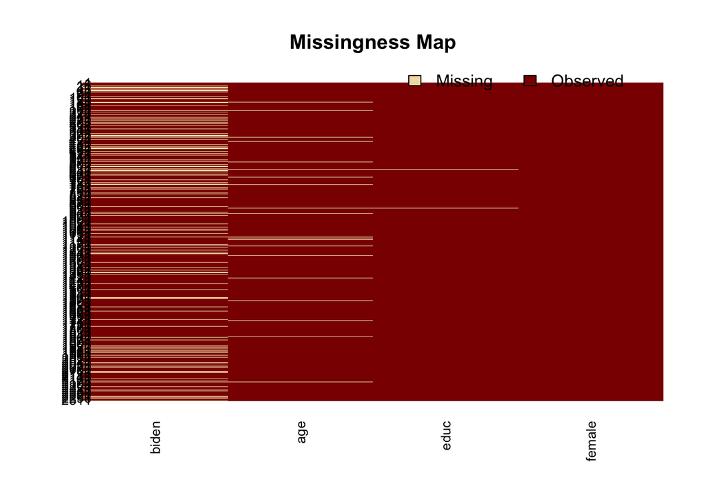

Contents below show results of multiple imputation using `Amelia`.

```
## List of 5
##  $ imp1:'data.frame':    2323 obs. of  4 variables:
##   ..$ biden : num [1:2323] 90 70 60 50 60 85 60 50 50 70 ...
##   ..$ female: num [1:2323] 0 1 0 1 1 1 1 0 1 0 ...
##   ..$ age   : num [1:2323] 19 51 27 43 38 27 28 31 32 51 ...
##   ..$ educ  : num [1:2323] 12 14 14 14 14 16 12 15 13 14 ...
##  $ imp2:'data.frame':    2323 obs. of  4 variables:
##   ..$ biden : num [1:2323] 90 70 60 50 60 85 60 50 50 70 ...
##   ..$ female: num [1:2323] 0 1 0 1 1 1 1 0 1 0 ...
##   ..$ age   : num [1:2323] 19 51 27 43 38 27 28 31 32 51 ...
##   ..$ educ  : num [1:2323] 12 14 14 14 14 16 12 15 13 14 ...
##  $ imp3:'data.frame':    2323 obs. of  4 variables:
##   ..$ biden : num [1:2323] 90 70 60 50 60 85 60 50 50 70 ...
##   ..$ female: num [1:2323] 0 1 0 1 1 1 1 0 1 0 ...
##   ..$ age   : num [1:2323] 19 51 27 43 38 27 28 31 32 51 ...
##   ..$ educ  : num [1:2323] 12 14 14 14 14 16 12 15 13 14 ...
##  $ imp4:'data.frame':    2323 obs. of  4 variables:
##   ..$ biden : num [1:2323] 90 70 60 50 60 85 60 50 50 70 ...
##   ..$ female: num [1:2323] 0 1 0 1 1 1 1 0 1 0 ...
##   ..$ age   : num [1:2323] 19 51 27 43 38 27 28 31 32 51 ...
##   ..$ educ  : num [1:2323] 12 14 14 14 14 16 12 15 13 14 ...
##  $ imp5:'data.frame':    2323 obs. of  4 variables:
##   ..$ biden : num [1:2323] 90 70 60 50 60 85 60 50 50 70 ...
##   ..$ female: num [1:2323] 0 1 0 1 1 1 1 0 1 0 ...
##   ..$ age   : num [1:2323] 19 51 27 43 38 27 28 31 32 51 ...
##   ..$ educ  : num [1:2323] 12 14 14 14 14 16 12 15 13 14 ...
##  - attr(*, "class")= chr [1:2] "mi" "list"
```

[output not shown]

```
##
## Call:
## lm(formula = biden ~ age + female + educ^2, data = biden_data)
##
## Residuals:
##    Min     1Q Median     3Q    Max
##  -67.1  -14.7    0.7   18.9   45.1
##
## Coefficients:
##             Estimate Std. Error t value Pr(>|t|)
## (Intercept)  68.6210     3.5960   19.08  < 2e-16 ***
## age           0.0419     0.0325    1.29      0.2
## female        6.1961     1.0967    5.65  1.9e-08 ***
## educ         -0.8887     0.2247   -3.96  7.9e-05 ***
## ---
## Signif. codes:  0 '***' 0.001 '**' 0.01 '*' 0.05 '.' 0.1 ' ' 1
##
## Residual standard error: 23.2 on 1803 degrees of freedom
## Multiple R-squared:  0.0272, Adjusted R-squared:  0.0256
## F-statistic: 16.8 on 3 and 1803 DF,  p-value: 8.88e-11
```

```
## Multiple Imputation Model
```

```
## # A tibble: 20 × 6
##       id        term estimate std.error statistic   p.value
##    <chr>       <chr>    <dbl>     <dbl>     <dbl>     <dbl>
## 1   imp1 (Intercept)  69.1479    2.9695     23.29 5.86e-108
## 2   imp1         age   0.0470    0.0275      1.71  8.76e-02
## 3   imp1      female   5.2523    0.9584      5.48  4.71e-08
## 4   imp1        educ  -0.9257    0.1846     -5.02  5.68e-07
## 5   imp2 (Intercept)  69.6460    2.9983     23.23 1.75e-107
## 6   imp2         age   0.0402    0.0278      1.44  1.49e-01
## 7   imp2      female   5.1902    0.9676      5.36  8.95e-08
## 8   imp2        educ  -0.9302    0.1860     -5.00  6.10e-07
## 9   imp3 (Intercept)  66.9357    3.0281     22.10  2.06e-98
## 10  imp3         age   0.0174    0.0280      0.62  5.36e-01
## 11  imp3      female   6.0995    0.9762      6.25  4.92e-10
## 12  imp3        educ  -0.6842    0.1879     -3.64  2.77e-04
## 13  imp4 (Intercept)  68.6858    3.0061     22.85 2.18e-104
## 14  imp4         age   0.0519    0.0279      1.86  6.31e-02
## 15  imp4      female   6.0648    0.9717      6.24  5.14e-10
## 16  imp4        educ  -0.9292    0.1866     -4.98  6.84e-07
## 17  imp5 (Intercept)  67.9826    2.9904     22.73 1.87e-103
## 18  imp5         age   0.0338    0.0277      1.22  2.22e-01
## 19  imp5      female   5.2736    0.9620      5.48  4.67e-08
## 20  imp5        educ  -0.7856    0.1852     -4.24  2.30e-05
```

### Compare regression results

```
##          term estimate std.error estimate.mi std.error.mi
## 1 (Intercept)  68.6210    3.5960      68.480       3.2148
## 2         age   0.0419    0.0325       0.038       0.0314
## 3      female   6.1961    1.0967       5.576       1.0922
## 4        educ  -0.8887    0.2247      -0.851       0.2228
```

According to the comparison of old model and new model, there are not much difference betwen the original model and the new model with multiple imputation. There are three possible explanations. First, the amount of missing values in the data is not big enough to influence the results. So multiple imputation would have very limited effect on model improvement. Second, the pattern of missingness may be Missing Completely at Random (MCAR) or Missing at Random (MAR). So the imputation does not greatly influence the relationship between the response `biden` and the predictors `age`, `gender` and `educ`. Third, my solution to the problem against multivariate normality is not good enough.